# Machine Learning 2019: Tree-Based Methods

Sonali Narang

10/28/2019

## Tree-Based Methods

Decision tree is a type of supervised learning algorithm that can be used in both regression and classification problems. Tree-based methods works for both categorical and continuous input and output variables.

## The Carseats Dataset

400 Observations, 11 variables Response Variable: Sales/High

```r
data("Carseats")
carseats = Carseats
head(carseats)
```

|  | Sales | CompPrice | Income | Advertising | Population | Price | ShelveLoc | Age | Education | Urban | US |
| --- | --- | --- | --- | --- | --- | --- | --- | --- | --- | --- | --- |
| 1 | 9.50 | 138 | 73 | 11 | 276 | 120 | Bad | 42 | 17 | Yes | Yes |
| 2 | 11.22 | 111 | 48 | 16 | 260 | 83 | Good | 65 | 10 | Yes | Yes |
| 3 | 10.06 | 113 | 35 | 10 | 269 | 80 | Medium | 59 | 12 | Yes | Yes |
| 4 | 7.40 | 117 | 100 | 4 | 466 | 97 | Medium | 55 | 14 | Yes | Yes |
| 5 | 4.15 | 141 | 64 | 3 | 340 | 128 | Bad | 38 | 13 | Yes | No |
| 6 | 10.81 | 124 | 113 | 13 | 501 | 72 | Bad | 78 | 16 | No | Yes |

```r
#convert quantitative variable Sales into a binary response
High = ifelse(carseats$Sales<=8, "No", "Yes")
carseats = data.frame(carseats, High)

head(carseats)
```

|  | Sales | CompPrice | Income | Advertising | Population | Price | ShelveLoc | Age | Education | Urban | US | High |
| --- | --- | --- | --- | --- | --- | --- | --- | --- | --- | --- | --- | --- |
| 1 | 9.50 | 138 | 73 | 11 | 276 | 120 | Bad | 42 | 17 | Yes | Yes | Yes |
| 2 | 11.22 | 111 | 48 | 16 | 260 | 83 | Good | 65 | 10 | Yes | Yes | Yes |
| 3 | 10.06 | 113 | 35 | 10 | 269 | 80 | Medium | 59 | 12 | Yes | Yes | Yes |
| 4 | 7.40 | 117 | 100 | 4 | 466 | 97 | Medium | 55 | 14 | Yes | Yes | No |
| 5 | 4.15 | 141 | 64 | 3 | 340 | 128 | Bad | 38 | 13 | Yes | No | No |
| 6 | 10.81 | 124 | 113 | 13 | 501 | 72 | Bad | 78 | 16 | No | Yes | Yes |

## Classification Tree

Input variables (X) can be continuous or categorical. Response variable (Y) is categorical (usually binary): in this case Sales/High.

```r
#set seed to make results reproducible
set.seed(29)

#split data into train and test subset (250 and 150 respectively)
train = sample(1:nrow(carseats), 250)

#Fit train subset of data to model
tree.carseats = tree(High~.-Sales, carseats, subset=train)
summary(tree.carseats)
```

```
##
## Classification tree:
## tree(formula = High ~ . - Sales, data = carseats, subset = train)
## Variables actually used in tree construction:
## [1] "ShelveLoc"   "Price"       "Age"         "CompPrice"   "Population"
## [6] "Advertising" "Income"      "US"
## Number of terminal nodes:  24
## Residual mean deviance:  0.3436 = 77.65 / 226
## Misclassification error rate: 0.072 = 18 / 250
```

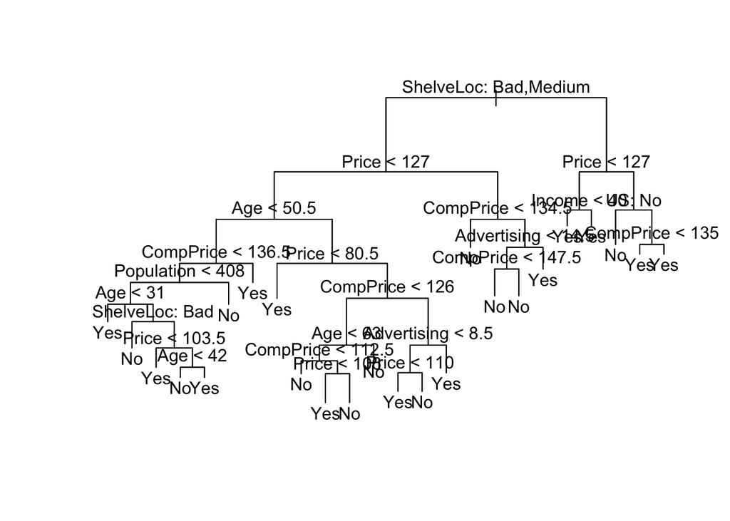

```r
#Visualize tree
plot(tree.carseats)
text(tree.carseats, pretty=0)
```

```r
#each of the terminal nodes are labeled Yes or No. The variables and the value of the splitting choice are shown at each terminal node.

#Use model on test set, predict class labels
tree.pred = predict(tree.carseats, carseats[-train,], type="class")

#Misclassification table to evaluate error
with(carseats[-train,], table(tree.pred, High))
```

```
##          High
## tree.pred No Yes
##       No  71  20
##       Yes 17  42
```

```r
#Calculate error by summing up the diagonals and dividing by number of total predictions
mc = (71 + 42) / 150
mc
```

```
## [1] 0.7533333
```

## Pruning using cross-validation

Pruning is a method to cut back the tree to prevent over-fitting.

```r
#cross-validation to prune the tree using cv.tree
cv.carseats = cv.tree(tree.carseats, FUN = prune.misclass)

#Sizes of the trees as they were pruned back, the deviances as the pruning proceeded, and cost complexity parameter used in the process.
cv.carseats
```

```
## $size
##  [1] 24 21 18 14 12  9  7  5  4  2  1
##
## $dev
##  [1]  69  68  63  65  69  73  76  75  83  92 104
##
## $k
##  [1] -Inf  0.0  1.0  1.5  2.5  3.0  3.5  4.0  6.0  7.5 25.0
##
## $method
## [1] "misclass"
##
## attr(,"class")
## [1] "prune"         "tree.sequence"
```

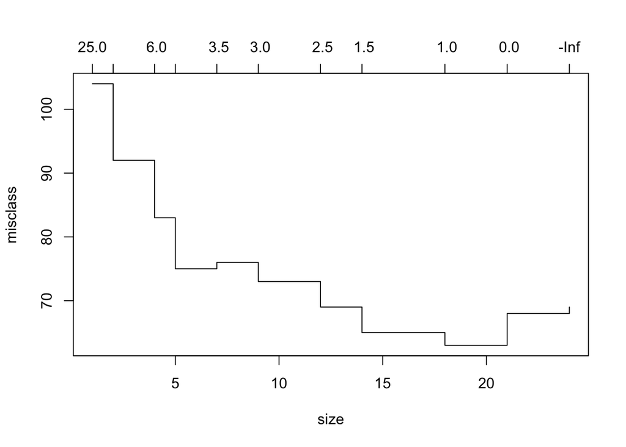

```r
#Visualize
plot(cv.carseats)
```

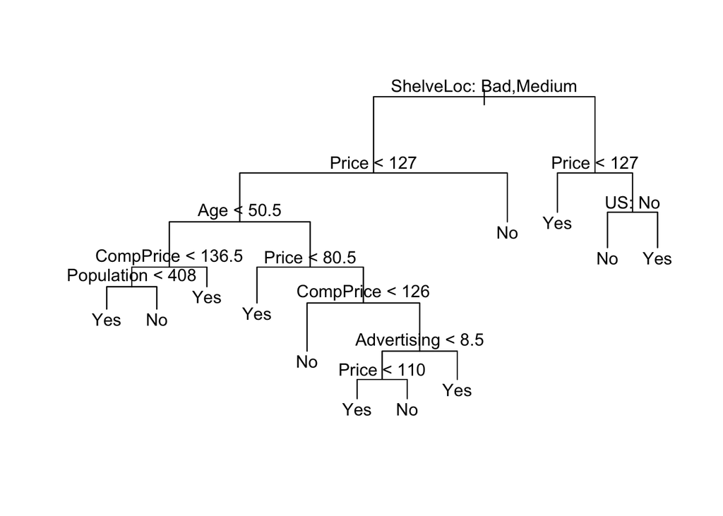

```r
#Prune tree to a size of 12
prune.carseats = prune.misclass(tree.carseats, best = 12)

#Visualize tree
plot(prune.carseats)
text(prune.carseats, pretty=0)
```

```r
#Evaluate on test set
tree.pred = predict(prune.carseats, carseats[-train,], type="class")

#Misclassification
with(carseats[-train,], table(tree.pred, High))
```

```
##          High
## tree.pred No Yes
##       No  66  21
##       Yes 22  41
```

```r
#Error
mc_pruning = (66 + 41) / 150
mc_pruning
```

```
## [1] 0.7133333
```

```r
##pruning did not increase misclassification error by too much and resulted in a simpler tree!!
```

Pruning did not increase misclassification error by too much and resulted in a simpler tree!!

Decision trees suffer from high variance, meaning if you split the training data into 2 parts at random, and fit a decision tree to both halves, the results that you get could be very different.

Bagging and boosting are technique used to reduce the variance of your predictions.

## The Boston Housing Dataset

506 Observations, 14 variables Response Variable: medv (median value of owner-occupied homes for each suburb)

```r
data("Boston")
boston = Boston
head(Boston)
```

|  | crim | zn | indus | chas | nox | rm | age | dis | rad | tax | ptratio | black | lstat | medv |
| --- | --- | --- | --- | --- | --- | --- | --- | --- | --- | --- | --- | --- | --- | --- |
| 1 | 0.00632 | 18 | 2.31 | 0 | 0.538 | 6.575 | 65.2 | 4.0900 | 1 | 296 | 15.3 | 396.90 | 4.98 | 24.0 |
| 2 | 0.02731 | 0 | 7.07 | 0 | 0.469 | 6.421 | 78.9 | 4.9671 | 2 | 242 | 17.8 | 396.90 | 9.14 | 21.6 |
| 3 | 0.02729 | 0 | 7.07 | 0 | 0.469 | 7.185 | 61.1 | 4.9671 | 2 | 242 | 17.8 | 392.83 | 4.03 | 34.7 |
| 4 | 0.03237 | 0 | 2.18 | 0 | 0.458 | 6.998 | 45.8 | 6.0622 | 3 | 222 | 18.7 | 394.63 | 2.94 | 33.4 |
| 5 | 0.06905 | 0 | 2.18 | 0 | 0.458 | 7.147 | 54.2 | 6.0622 | 3 | 222 | 18.7 | 396.90 | 5.33 | 36.2 |
| 6 | 0.02985 | 0 | 2.18 | 0 | 0.458 | 6.430 | 58.7 | 6.0622 | 3 | 222 | 18.7 | 394.12 | 5.21 | 28.7 |

## Bagging: Random Forest

Bagging involves creating multiple copies of the original training dataset using the bootstrap, fitting a separate decision tree to each copy, and then combining all of the trees in order to create a single predictive model. Each tree is built on a bootstrapped dataset, independent of the other trees.

Random Forest: Each time a split in a tree is considered, a random sample of m predictors is chosen as split candidates from the full set of p predictors. The split is allowed to use only one of those m predictors.

```r
#set seed for reproducibility
set.seed(29)

#split into train and test sets (300 and 206 respectively)
train = sample(1:nrow(boston), 300)

#fit training subset of data to model
rf.boston = randomForest(medv~., data = boston, subset = train)
rf.boston
```

```
##
## Call:
##  randomForest(formula = medv ~ ., data = boston, subset = train)
##                Type of random forest: regression
##                      Number of trees: 500
## No. of variables tried at each split: 4
##
##           Mean of squared residuals: 12.86824
##                     % Var explained: 83.94
```

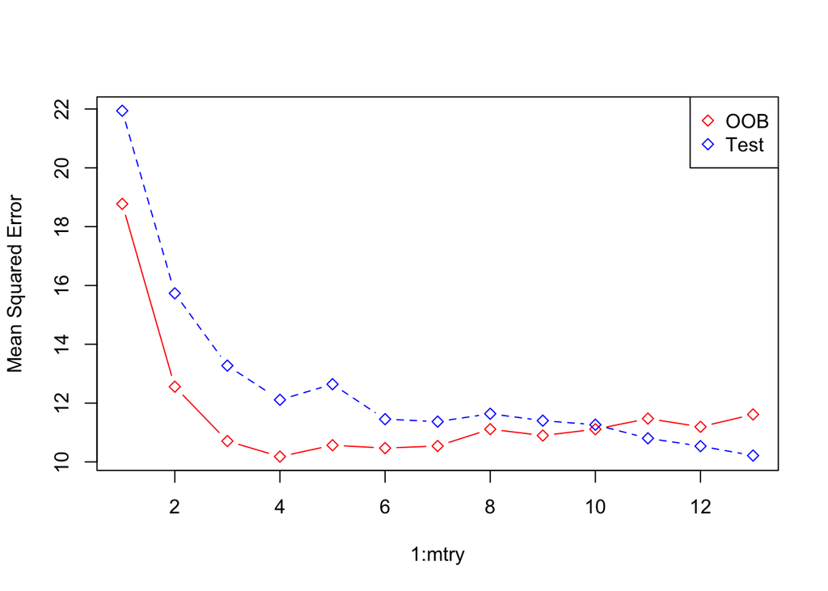

```r
#summary of rf.boston gives information about the number of trees, the mean squared residuals (MSR), and the percentage of variance explained

#No. of variables tried at each split: 4
#Each time the tree comes to split a node, 4 variables would be selected at random, then the split would be confined to 1 of those 4 variables.

##Lets try a range of mtry (number of variables selected at random at each split)

oob.err = double(13)
test.err = double(13)

#In a loop of mtry from 1 to 13, you first fit the randomForest to the train dataset
for(mtry in 1:13){
  fit = randomForest(medv~., data = boston, subset=train, mtry=mtry, ntree = 350)
  oob.err[mtry] = fit$mse[350] ##extract Mean-squared-error
  pred = predict(fit, boston[-train,]) #predict on test dataset
  test.err[mtry] = with(boston[-train,], mean( (medv-pred)^2 )) #compute test error
}

#Visualize
matplot(1:mtry, cbind(test.err, oob.err), pch = 23, col = c("red", "blue"), type = "b", ylab="Mean Squared Error")
legend("topright", legend = c("OOB", "Test"), pch = 23, col = c("red", "blue"))
```

## Boosting

Boosting is another approach to improve the predictions resulting from a decision tree. Trees are grown sequentially: each tree is grown using information from previously grown trees. Each tree is fitted on a modified version of the original dataset.

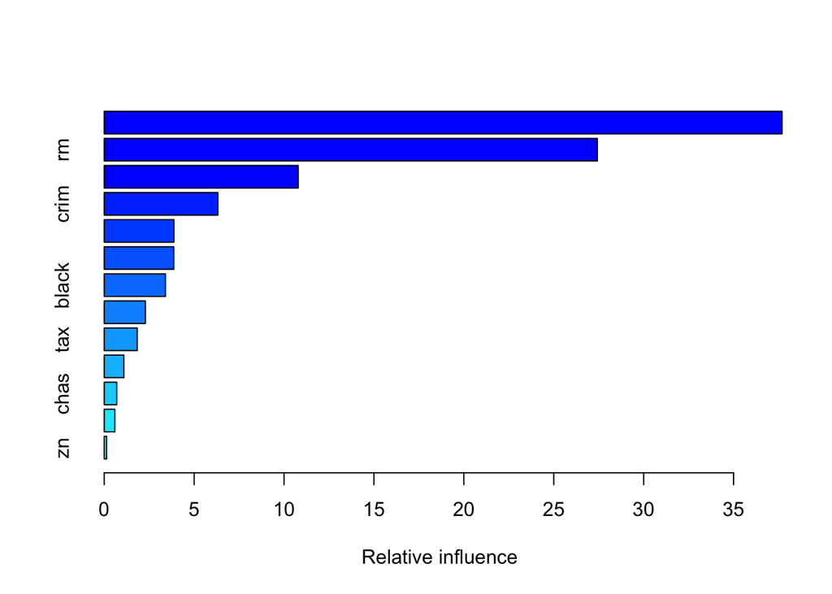

|  | var | rel.inf |
| --- | --- | --- |
| lstat | lstat | 37.6982917 |
| rm | rm | 27.4231506 |
| dis | dis | 10.7870570 |
| crim | crim | 6.3190588 |
| nox | nox | 3.8741970 |
| age | age | 3.8660387 |
| black | black | 3.4055088 |
| ptratio | ptratio | 2.2861013 |
| tax | tax | 1.8341376 |
| indus | indus | 1.0918593 |

[output cut: 3 more lines]

```r
#Gradient Boosting Model
boost.boston = gbm(medv~., data = boston[train,], distribution = "gaussian", n.trees = 10000, shrinkage = 0.01, interaction.depth = 4)

#Variable Importance Plot
summary(boost.boston)
```

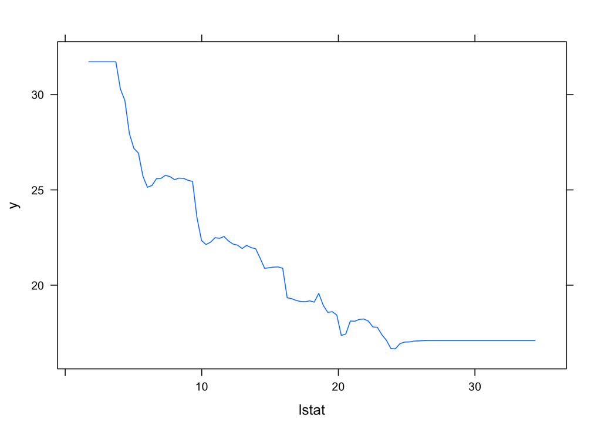

```r
#Visualize important variables of interest
plot(boost.boston,i="lstat")
```

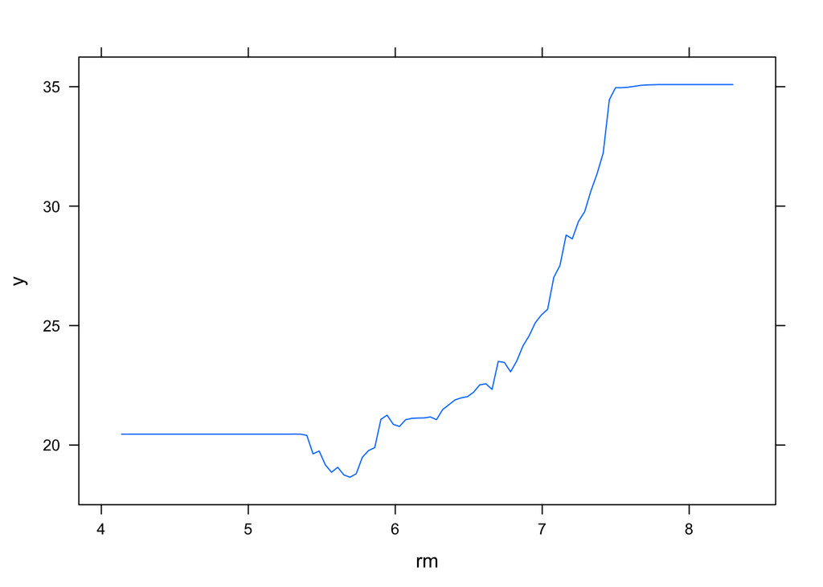

```r
plot(boost.boston,i="rm")
```

```r
#Predict on test set
n.trees = seq(from = 100, to = 10000, by = 100)
predmat = predict(boost.boston, newdata = boston[-train,], n.trees = n.trees)
dim(predmat)
```

```
## [1] 206 100
```

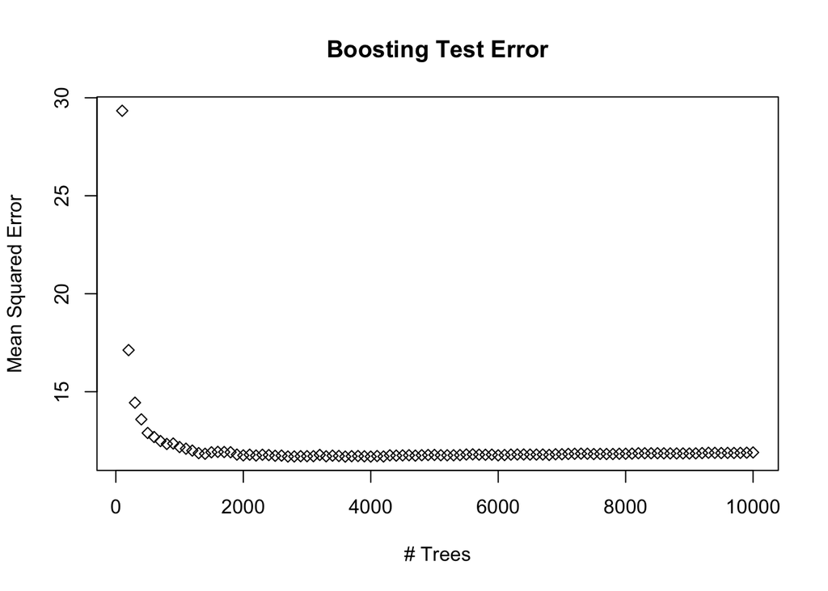

```r
#Visualize Boosting Error Plot
boost.err = with(boston[-train,], apply( (predmat - medv)^2, 2, mean) )
plot(n.trees, boost.err, pch = 23, ylab = "Mean Squared Error", xlab = "# Trees", main = "Boosting Test Error")
abline(h = min(test.err), col = "red")
```

## Homework

1. Attempt a regression tree-based method (not covered in this tutorial) on a reasonable dataset of your choice. Explain the results.
2. Attempt both a bagging and boosting method on a reasonable dataset of your choice. Explain the results.

```r
data("Wage")
head(Wage)
```

|  | year | age | maritl | race | education | region | jobclass | health | health_ins | logwage | wage |
| --- | --- | --- | --- | --- | --- | --- | --- | --- | --- | --- | --- |
| 231655 | 2006 | 18 | 1. Never Married | 1. White | 1. < HS Grad | 2. Middle Atlantic | 1. Industrial | 1. <=Good | 2. No | 4.318063 | 75.04315 |
| 86582 | 2004 | 24 | 1. Never Married | 1. White | 4. College Grad | 2. Middle Atlantic | 2. Information | 2. >=Very Good | 2. No | 4.255273 | 70.47602 |
| 161300 | 2003 | 45 | 2. Married | 1. White | 3. Some College | 2. Middle Atlantic | 1. Industrial | 1. <=Good | 1. Yes | 4.875061 | 130.98218 |
| 155159 | 2003 | 43 | 2. Married | 3. Asian | 4. College Grad | 2. Middle Atlantic | 2. Information | 2. >=Very Good | 1. Yes | 5.041393 | 154.68529 |
| 11443 | 2005 | 50 | 4. Divorced | 1. White | 2. HS Grad | 2. Middle Atlantic | 2. Information | 1. <=Good | 1. Yes | 4.318063 | 75.04315 |
| 376662 | 2008 | 54 | 2. Married | 1. White | 4. College Grad | 2. Middle Atlantic | 2. Information | 2. >=Very Good | 1. Yes | 4.845098 | 127.11574 |

```r
str(Wage)
```

```
## 'data.frame':    3000 obs. of  11 variables:
##  $ year      : int  2006 2004 2003 2003 2005 2008 2009 2008 2006 2004 ...
##  $ age       : int  18 24 45 43 50 54 44 30 41 52 ...
##  $ maritl    : Factor w/ 5 levels "1. Never Married",..: 1 1 2 2 4 2 2 1 1 2 ...
##  $ race      : Factor w/ 4 levels "1. White","2. Black",..: 1 1 1 3 1 1 4 3 2 1 ...
##  $ education : Factor w/ 5 levels "1. < HS Grad",..: 1 4 3 4 2 4 3 3 3 2 ...
##  $ region    : Factor w/ 9 levels "1. New England",..: 2 2 2 2 2 2 2 2 2 2 ...
##  $ jobclass  : Factor w/ 2 levels "1. Industrial",..: 1 2 1 2 2 2 1 2 2 2 ...
##  $ health    : Factor w/ 2 levels "1. <=Good","2. >=Very Good": 1 2 1 2 1 2 2 1 2 2 ...
##  $ health_ins: Factor w/ 2 levels "1. Yes","2. No": 2 2 1 1 1 1 1 1 1 1 ...
##  $ logwage   : num  4.32 4.26 4.88 5.04 4.32 ...
##  $ wage      : num  75 70.5 131 154.7 75 ...
```

Predict wages based on all other inputs (excepting logwage)

```r
#set seed to make results reproducible
set.seed(10)


#split data into train and test subset (2000 and 1000 respectively)
trn_index = sample(1:nrow(Wage), 2000)
train = Wage[trn_index,]
test = Wage[-trn_index,]

#Fit train subset of data to model
wage_tree = tree(wage~.-logwage, data = train)
summary(wage_tree)
```

```
##
## Regression tree:
## tree(formula = wage ~ . - logwage, data = train)
## Variables actually used in tree construction:
## [1] "education"  "health_ins" "maritl"
## Number of terminal nodes:  7
## Residual mean deviance:  1289 = 2569000 / 1993
## Distribution of residuals:
##     Min.  1st Qu.   Median     Mean  3rd Qu.     Max.
## -102.600  -20.500   -4.333    0.000   15.150  224.000
```

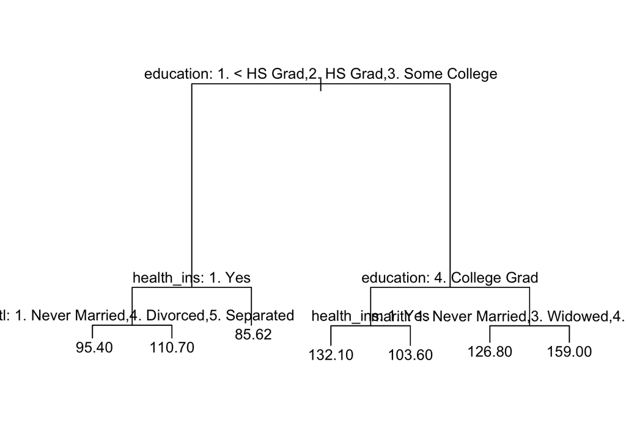

```r
#Visualize tree
plot(wage_tree)
text(wage_tree, pretty=0)
```

## evaluate tree model:

```r
#Use model on test set to predict wages
tree.pred = predict(wage_tree, test, type = "vector")

# Calculate mean square error (training MSE = 1289 -- listed in model summary)
MSE = mean((tree.pred - test$wage)^2)
paste("Regression tree MSE: ", MSE)
```

```
## [1] "Regression tree MSE:  1163.85401105149"
```

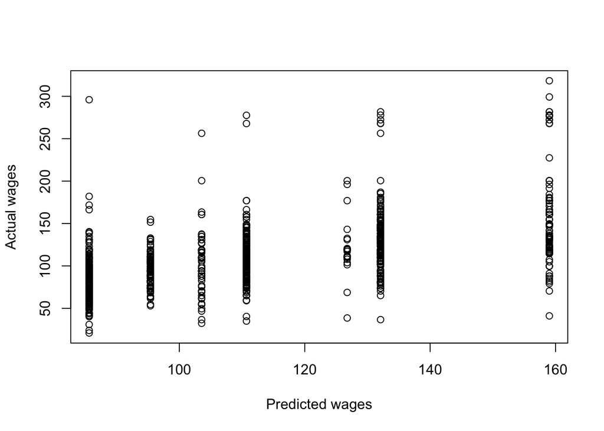

```r
plot(tree.pred, test$wage, xlab = "Predicted wages", ylab = "Actual wages")
```

**Prune:**

```r
#cross-validation to prune the tree using cv.tree
wage_cv = cv.tree(wage_tree, FUN = prune.tree)

#Sizes of the trees as they were pruned back, the deviances as the pruning proceeded, and cost complexity parameter used in the process.
wage_cv
```

```
## $size
## [1] 7 6 5 4 3 2 1
##
## $dev
## [1] 2694595 2719159 2729924 2765867 2991370 2992449 3619707
##
## $k
## [1]      -Inf  40575.87  52781.17  62345.11 120785.84 122568.83 648946.70
##
## $method
## [1] "deviance"
##
## attr(,"class")
## [1] "prune"         "tree.sequence"
```

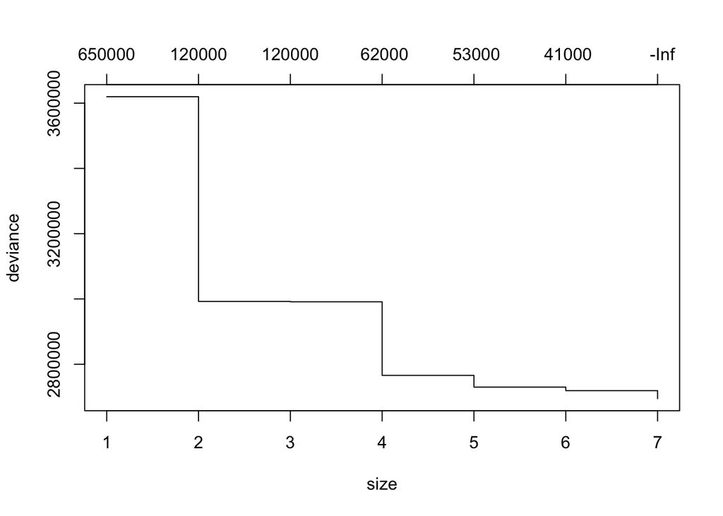

```r
#Visualize
plot(wage_cv)
```

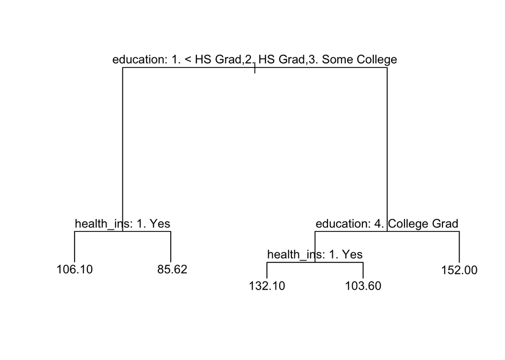

```r
#Prune tree to a size of 12
wage_prune = prune.tree(wage_tree, best = 5)

#Visualize tree
plot(wage_prune)
text(wage_prune, pretty=0)
```

```r
#Evaluate on test set
tree.pred = predict(wage_prune, test, type="vector")


# Mean Square Error
MSE = mean((tree.pred - test$wage)^2)
paste("Pruned regression tree MSE: ", MSE)
```

```
## [1] "Pruned regression tree MSE:  1188.59952595922"
```

```r
## pruning slightly increased MSE here
```

**Bagging RF:**

```r
#fit training data to model
wage_rf = randomForest(wage~.-logwage, data = train)
wage_rf
```

```
##
## Call:
##  randomForest(formula = wage ~ . - logwage, data = train)
##                Type of random forest: regression
##                      Number of trees: 500
## No. of variables tried at each split: 3
##
##           Mean of squared residuals: 1229.086
##                     % Var explained: 32.04
```

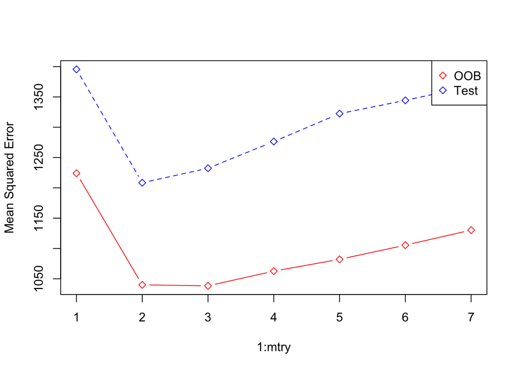

```r
#No. of variables tried at each split: 3


## Try a range of mtry:
oob.err = double(7)
test.err = double(7)

#In a loop of mtry from 1 to 7, fit the randomForest to the train dataset
for(mtry in 1:7){
  fit = randomForest(wage~.-logwage, data = train, mtry=mtry, ntree = 350)
  oob.err[mtry] = fit$mse[350] ##extract Mean-squared-error
  pred = predict(fit, test) #predict on test dataset
  test.err[mtry] = with(test, mean( (wage-pred)^2 )) #compute test error
}

#Visualize
matplot(1:mtry, cbind(test.err, oob.err), pch = 23, col = c("red", "blue"), type = "b", ylab="Mean Squared Error")
legend("topright", legend = c("OOB", "Test"), pch = 23, col = c("red", "blue"))
```

**Boosting:**

```r
#Gradient Boosting Model
wage_boost = gbm(wage~.-logwage, data = train, distribution = "gaussian", n.trees = 10000, shrinkage = 0.01, interaction.depth = 4)
```

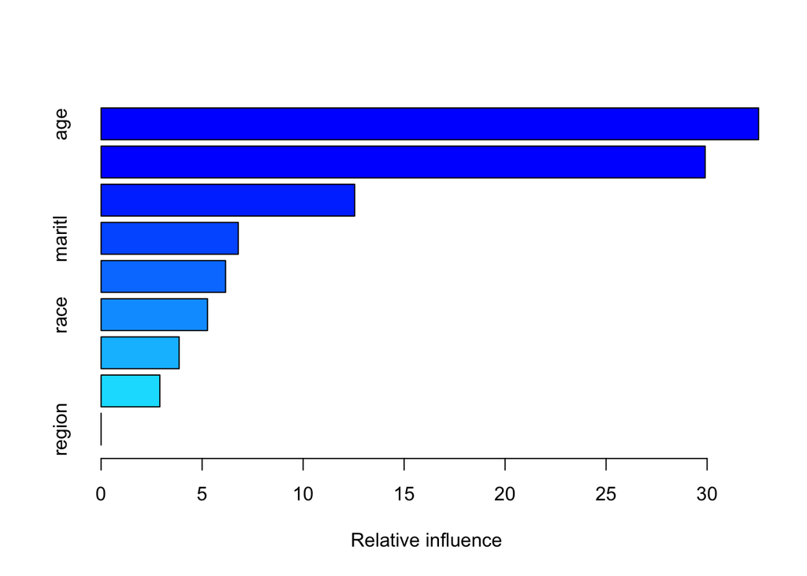

|  | var | rel.inf |
| --- | --- | --- |
| age | age | 32.548866 |
| education | education | 29.906368 |
| year | year | 12.553388 |
| maritl | maritl | 6.789604 |
| health_ins | health_ins | 6.161764 |
| race | race | 5.267764 |
| jobclass | jobclass | 3.863218 |
| health | health | 2.909027 |
| region | region | 0.000000 |

```r
#Variable Importance Plot
summary(wage_boost)
```

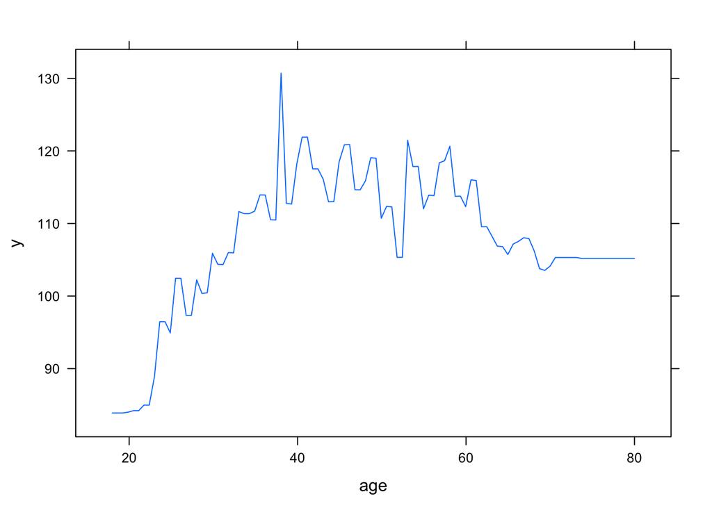

```r
#Visualize important variables of interest
plot(wage_boost,i="age")
```

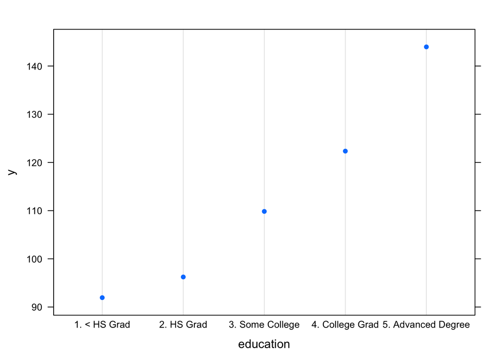

```r
plot(wage_boost,i="education")
```

```r
#Predict on test set
n.trees = seq(from = 100, to = 10000, by = 100)
pred = predict(wage_boost, newdata = test, n.trees = n.trees)
dim(pred)
```

```
## [1] 1000  100
```

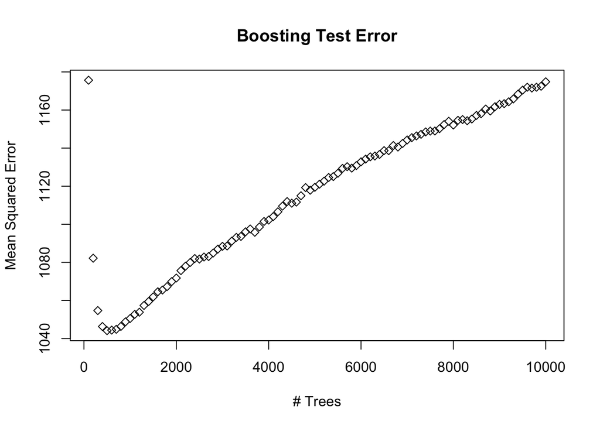

```r
#Visualize Boosting Error Plot
boost.err = with(test, apply( (pred - wage)^2, 2, mean) )
plot(n.trees, boost.err, pch = 23, ylab = "Mean Squared Error", xlab = "# Trees", main = "Boosting Test Error")
abline(h = min(test.err), col = "red")
```

It looks like 2 or 3 variables tried at the split generates the best model for bagging RF approach, with a mean sq error around 1200. It seems pretty clear that boosting is not a great approach here. After about 500 trees, the model starts to deteriorate.